# Inseguridad Social

Profesora Valentina Andrade/ Ayudante Dafne Vargas/ Estudiante Vicente Godoy

2022-12-05

### **Abstract**

En chile, ha aumentado la sensacion de inseguridad, o al menos se ha manifestado- sea en la televison o en las redes sociales- todas las inseguridad de la pobacion chilena .Por ende, es de suma importancia lograr responder el Por qué surge este sentimiento de inseguridad y qué factores inciden en esta percepcion de los y las chilenas. Por lo cual, se recogieron datos sobre 4 variables que pudiesen incidir sobre la inseguridad, a saber: a)percepcion de conflicto entre chilesnos e inmigrantes peruanos. b) justificacion de la violencia. c) Confianza en Carabineros. d) Edad. Los resultados, a grandes razgos, indicaron que, en primer lugar, aquellos que perciben mas conflictos entre hombres y mayores son menos seguros; aquellas que nunca justifican la violencia se sienten mas seguros; aquellos que nunca justifican la violencia se sienten mas seguros; y, finalmente, los adultos jovenes (de 18 a 26) son la poblacion menos segura

### **Introduccion**

En chile, producto de la revuelta social acontecida el 18 de Octubre de 2019 y producto de la pandemia que tendría su origen el 3 de marzo de 2020, comenzó un aparente o concreta subida de inseguridad social en la población chilena. El contenido de la información que se mostraban en los canales de televisión y en las redes sociales fue de una oleada incontrolable de noticias negativas que provocaba la necesidad de seguridad por parte del Estado y de una cantidad selecta de instituciones -pues con la revuelta la confianza en algunas instituciones como las fuerzas armadas quedaron fuera. En consecuencia, independiente de si la inseguridad sea mera percepción, es relevante indagar sobre aquellas fuerzas o situaciones sociales que inciden sobre la inseguridad social, o al menos comprender las situaciones que inciden sobre el comportamiento de las personas que las vuelven inseguras. A causa de esta situacion, la presenta investigacion indagó sobre algunos factores que podrian incidir en la seguridad y descubrir el perfil de los y las inseguras debido a situaciones sociales, ellas fueron, a saber: el conflicto entre chilenos y peruanos, el tramo de edad, la confianza en carabineros y la confianza en carabineros. Ademas, es relevante indagar sobre variables sociales puesto que, como señala Luneke (2021) ” la seguridad se hace cuidándose unos a otros, de manera asociativa, nunca solos”. Dicho de otra manera, mas alla de recaer en el autocuidado para prevenir y enfrentar la inseguridad, se debe indagar sobre lo social para lograr revertir la inseguridad en Chile

### **Analisis**

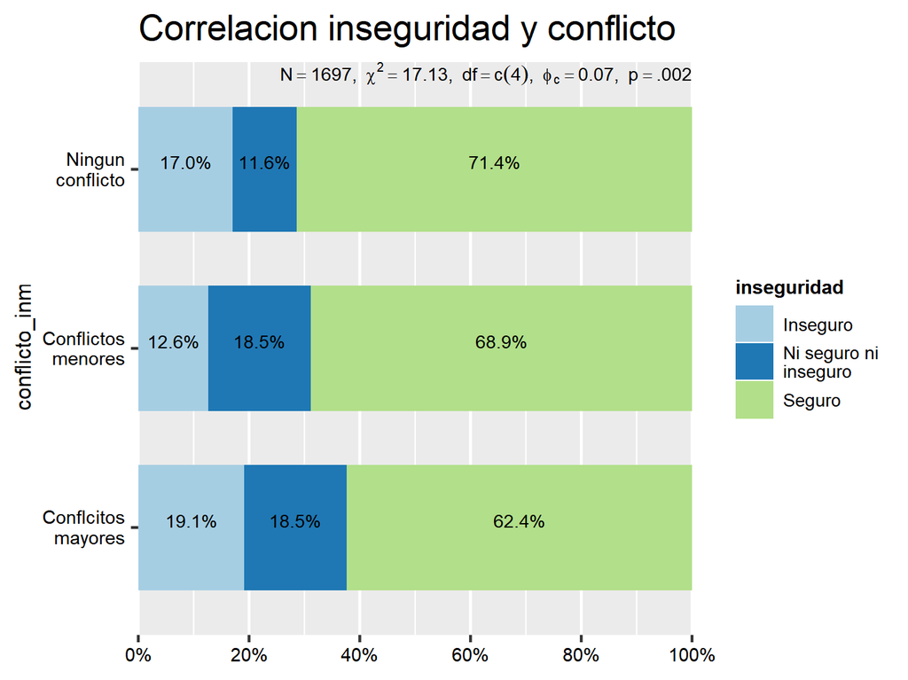

En segundo lugar, se correlacionó las variables de inseguridad y justificacion de la violencia (que estudiantes tiren piedras a carabineros). Esta ultima cabe señalar que se recodificó en tres opciones: “Nunca se justifica”, “En ocasiones se justifica” y “En general se justifica”. Los resultados fueron que el 68,1% de aquellas personas que nunca se justifica son seguras, un 63.4% los partidarios que en ocasiones se justifica y 57,9% los que en general se justifica.

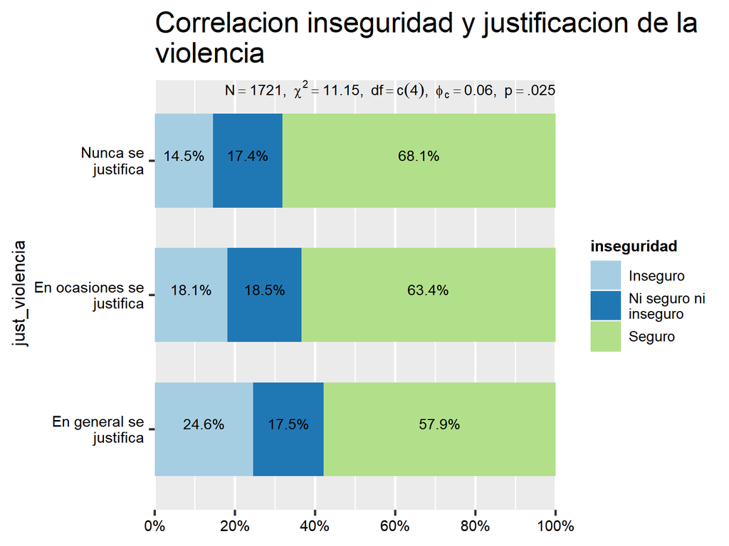

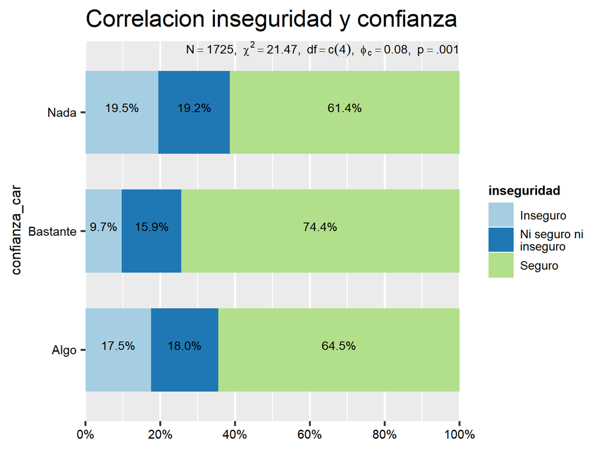

En cuarto y ultimo lugar, se aplicó la relacion entre la inseguridad y la edad, el cual esta ultima variable fue recodificada en tramos, el cual de los 18 años hasta los 26 años se mencionan como “Adultos jovenes”, de los 27 años a los 59 años como “Adultos” y finalmente de los 60 años en adelante como “adultos mayores”. Luego de esta recodificacion los resultados fueron que el 74,1% de los adultos mayores son seguros, el 63,9% de los adultos son seguros y el 49,4% de los adultos jovenes son seguros.

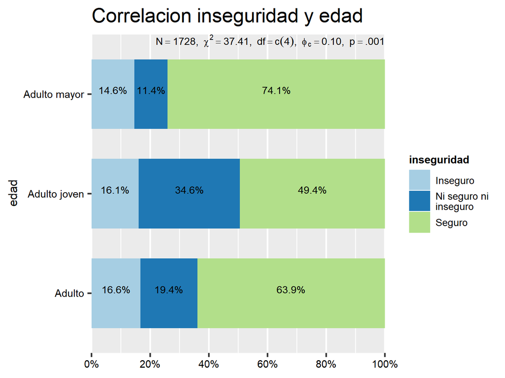

### **Conclusion**

En definitiva, se puede observar que a) la percepcion de conflicto entre chilenos y peruanos incide sobre la percepcion de inseguridad, puesto que existe una diferencia significativa de inseguridad entre los que perciben y no conflicto entre chilenos e inmigrantes.b) Hay incidencia de inseguridad entre los que justifican y no la violencia en cuanto a inseguridad. c)La correlacion entre inseguridad y confianza en carabinero se confirmó dado que los que confian en carabineros se perciben mas seguros con una diferencia significativa. d) El tramo de edad afecta en la inseguridad, puesto que los adultos jovenes son sustancialmente menos seguros que los adultos y adultos mayores.

### **Bibliografa**

Luneke Reyes, Alejandra. (2021). Inseguridad urbana, participación ciudadana y cuidado vecinal: la búsqueda por protección en los barrios. Revista INVI, 36(102), 302-327. https://dx.doi.org/10.4067/S0718-83582021000200302